# Assignment : Task II

Junhao Zhang

13/12/2020

Thid document contains the work for the Task II

```r
## Data
Data=read.csv("Task II.csv", header = TRUE)
head(Data)
```

```
##             id                  Email jumps X_value Y_value Z_value
## 1       amanda ag4399@tc.columbia.edu    65   2.867   3.247   2.258
## 2          dan dl3418@tc.columbia.edu    58   3.785   3.560   3.791
## 3        daisy yz3845@tc.columbia.edu    43   4.198   3.366   3.737
## 4     Yen-Ling yc3655@tc.columbia.edu    70   4.637   3.501   3.413
## 5       Aniket as6145@tc.columbia.edu    60   3.201   3.013   3.302
## 6 Junhao Zhang jz3248@tc.columbia.edu    56   2.835   3.377   2.579
```

```r
summary(Data)
```

```
##             id                       Email       jumps          X_value
##  amanda      :1   ag4399@tc.columbia.edu:1   Min.   :43.00   Min.   :2.617
##  Aniket      :1   as6145@tc.columbia.edu:1   1st Qu.:55.25   1st Qu.:2.859
##  daisy       :1   dl3418@tc.columbia.edu:1   Median :59.00   Median :3.427
##  dan         :1   jz3248@tc.columbia.edu:1   Mean   :60.12   Mean   :3.474
##  Junhao Zhang:1   qy2244@tc.columbia.edu:1   3rd Qu.:66.25   3rd Qu.:3.888
##  Qianhui Yuan:1   xr2146@tc.columbia.edu:1   Max.   :76.00   Max.   :4.637
##  (Other)     :2   (Other)               :2
##     Y_value         Z_value
##  Min.   :3.013   Min.   :2.258
##  1st Qu.:3.336   1st Qu.:2.566
##  Median :3.418   Median :3.357
##  Mean   :3.418   Mean   :3.235
##  3rd Qu.:3.516   3rd Qu.:3.751
##  Max.   :3.823   Max.   :4.272
##
```

```r
data=na.omit(Data)# omit the missing values
```

data set contains 6 variables. Name and email address of the member is rocorded. Moreover, number of jumpus and three mesurements were recorded.

Preparing Data

```r
# Remove the column with name and email, so it will not be included in the clustering
input=data[,3:6]
input
```

```
##   jumps X_value Y_value Z_value
## 1    65   2.867   3.247   2.258
## 2    58   3.785   3.560   3.791
## 3    43   4.198   3.366   3.737
## 4    70   4.637   3.501   3.413
## 5    60   3.201   3.013   3.302
## 6    56   2.835   3.377   2.579
## 7    53   3.653   3.459   2.528
## 8    76   2.617   3.823   4.272
```

K-means to identify the novices from the experts among the members who used only the app data

Packages required to run KMeans Clustering

```r
#factoextra to determine the optimal number clusters for a given clustering methods and for data visualization.
#NbClust for computing about 30 methods at once, in order to find the optimal number of clusters.
# ggplot2 for • Visualizing
library(factoextra)
library(NbClust)
library(ggplot2)
```

K means Xlustering

```r
# run K-means for an arbitrary K=3
kmeans(input,centers=3,nstart=20)
```

```
## K-means clustering with 3 clusters of sizes 1, 3, 4
##
## Cluster means:
##      jumps  X_value  Y_value  Z_value
## 1 43.00000 4.198000 3.366000 3.737000
## 2 70.33333 3.373667 3.523667 3.314333
## 3 56.75000 3.368500 3.352250 3.050000
##
## Clustering vector:
## 1 2 3 4 5 6 7 8
## 2 3 1 2 3 3 3 2
##
## Within cluster sum of squares by cluster:
## [1]  0.00000 65.30129 28.59426
##  (between_SS / total_SS =  87.4 %)
##
## Available components:
##
## [1] "cluster"      "centers"      "totss"        "withinss"     "tot.withinss"
## [6] "betweenss"    "size"         "iter"         "ifault"
```

However, in k means we have to decide the optimal number of k have better clustering. Therefore, we will see a way to identify the optimal k

We have to standarize the data since variables in the input have different scales

```r
# Standardize the data
df <- scale(input)
head(df)
```

```
##         jumps    X_value    Y_value     Z_value
## 1  0.47450212 -0.8476255 -0.7251359 -1.37049507
## 2 -0.20683426  0.4340220  0.6002220  0.77993373
## 3 -1.66684077  1.0106237 -0.2212458  0.70418477
## 4  0.96117095  1.6235248  0.3503941  0.24969102
## 5 -0.01216672 -0.3813180 -1.7159786  0.09398482
## 6 -0.40150179 -0.8923017 -0.1746678 -0.92020959
```

We are going to use Elbow method to find the optimum k

```r
#plot Elbow to identify the optimum number K
#Elbow Method for finding the optimal number of clusters
set.seed(123)
# Compute and plot wss for k = 2 to k = 6.
k.max <- 6
data <- df
wss <- sapply(1:k.max,
              function(k){kmeans(data, k, nstart=50,iter.max = 15 )$tot.withinss})
wss
```

```
## [1] 28.000000 17.706672  9.522648  6.389747  3.664048  2.102686
```

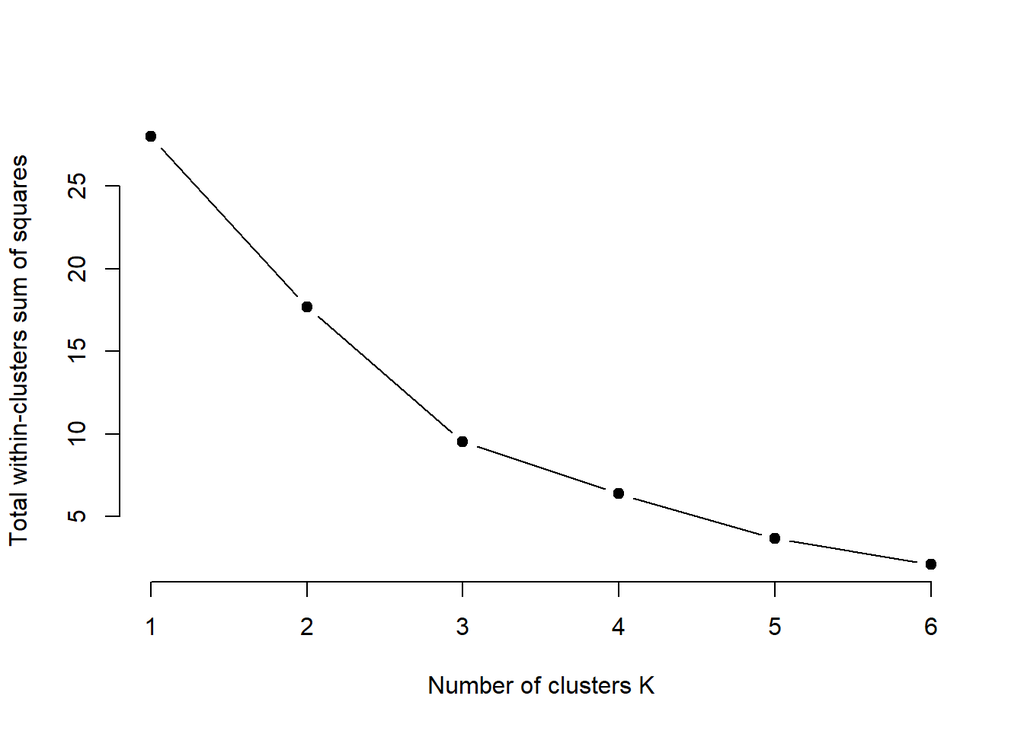

```r
plot(1:k.max, wss,
     type="b", pch = 19, frame = FALSE,
     xlab="Number of clusters K",
     ylab="Total within-clusters sum of squares")
```

According to the graph it can be identified that optimum k is 3. let’s choose K = 3 and run the K-means again.

```r
set.seed(123)
clusters=kmeans(data,centers=3,nstart=20)
clusters
```

```
## K-means clustering with 3 clusters of sizes 4, 1, 3
##
## Cluster means:
##        jumps    X_value    Y_value    Z_value
## 1 -0.1581674 -0.4678781 -0.6108079 -0.7971175
## 2  1.5451736 -1.1966581  1.7138614  1.4546606
## 3 -0.3041680  1.0227235  0.2431234  0.5779365
##
## Clustering vector:
## 1 2 3 4 5 6 7 8
## 1 3 3 3 1 1 1 2
##
## Within cluster sum of squares by cluster:
## [1] 4.828385 0.000000 4.694264
##  (between_SS / total_SS =  66.0 %)
##
## Available components:
##
## [1] "cluster"      "centers"      "totss"        "withinss"     "tot.withinss"
## [6] "betweenss"    "size"         "iter"         "ifault"
```

However here we need to identify the novices from the experts Therefore lets take K=2

```r
novices_experts=kmeans(data,centers=2,nstart=20)
novices_experts
```

```
## K-means clustering with 2 clusters of sizes 3, 5
##
## Cluster means:
##        jumps    X_value    Y_value    Z_value
## 1  0.7665034  0.2869629  0.8881592  0.8280951
## 2 -0.4599021 -0.1721778 -0.5328955 -0.4968571
##
## Clustering vector:
## 1 2 3 4 5 6 7 8
## 2 1 2 1 2 2 2 1
##
## Within cluster sum of squares by cluster:
## [1]  7.384102 10.322569
##  (between_SS / total_SS =  36.8 %)
##
## Available components:
##
## [1] "cluster"      "centers"      "totss"        "withinss"     "tot.withinss"
## [6] "betweenss"    "size"         "iter"         "ifault"
```

Here in the output clustering vector shows the two clusters where experts and novices

Now we willVisualize the obtained results

```r
str(novices_experts)
```

```
## List of 9
##  $ cluster     : Named int [1:8] 2 1 2 1 2 2 2 1
##   ..- attr(*, "names")= chr [1:8] "1" "2" "3" "4" ...
##  $ centers     : num [1:2, 1:4] 0.767 -0.46 0.287 -0.172 0.888 ...
##   ..- attr(*, "dimnames")=List of 2
##   .. ..$ : chr [1:2] "1" "2"
##   .. ..$ : chr [1:4] "jumps" "X_value" "Y_value" "Z_value"
##  $ totss       : num 28
##  $ withinss    : num [1:2] 7.38 10.32
##  $ tot.withinss: num 17.7
##  $ betweenss   : num 10.3
##  $ size        : int [1:2] 3 5
##  $ iter        : int 1
##  $ ifault      : int 0
##  - attr(*, "class")= chr "kmeans"
```

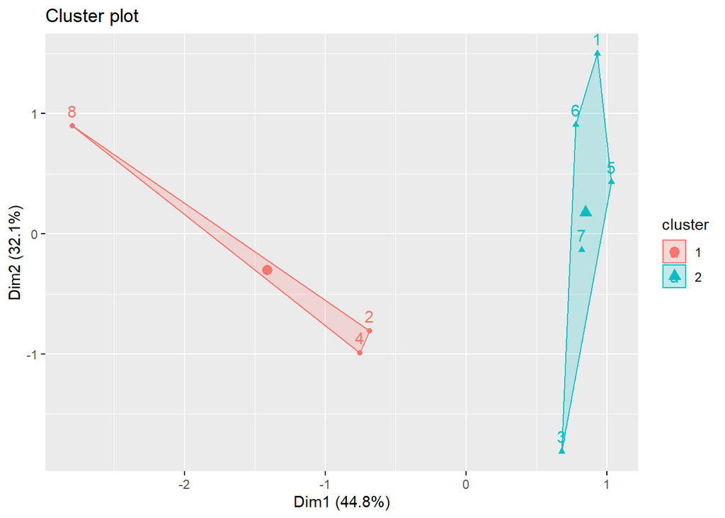

```r
fviz_cluster(novices_experts, data = data.frame(data))
```

Cluster plot gives the two clusters where red colour one indicates the experts and blue colour cluster indicates the novices.

Therefore, following members are identified as experts :dan, Yen-Ling and Qianhui Yuan

And identified novices from the experts are: amanda,daisy ,Aniket ,Junhao Zhang and Xinyuan.